# ProteomicAnalysis_UnwinECandHIPdata

## 4.6.2. Define shared significant proteins

sig_ec <- rownames(results_ec[results_ec$adj.P.Val < 0.05, ]) sig_hip <- rownames(results_hip[results_hip$adj.P.Val < 0.05, ])

shared <- intersect(sig_ec, sig_hip)

length(shared)

## 4.6.3. Build plotting dataframe

common <- intersect(rownames(results_ec), rownames(results_hip))

plot_df <- data.frame( protein = common, logFC_EC = results_ec[common, “logFC”], logFC_HIP = results_hip[common, “logFC”] )

plot_df$category <- ifelse(plot_df$protein %in% shared, “Shared Significant”, “Other”)

## 4.6.4. Plot comparison

geom_abline(slope = 1, intercept = 0, linetype = “dashed”) +

theme_minimal(base_size = 14) +

## 4.6.5. Plot comparison with top shared proteins highlighted

top_shared <- plot_df[plot_df$protein %in% shared, ] top_shared <- top_shared[order(-abs(top_shared$logFC_EC)), ][1:10, ]

ggplot(plot_df, aes(x = logFC_EC, y = logFC_HIP)) + geom_point(aes(color = category), alpha = 0.6) +

geom_text_repel( data = top_shared, aes(label = protein), size = 3 ) +

scale_color_manual(values = c( “Shared Significant” = “red”, “Other” = “grey” )) +

geom_abline(slope = 1, intercept = 0, linetype = “dashed”) +

theme_minimal(base_size = 14) +

labs( title = “Shared Differential Proteins (EC vs HIP)”, x = “EC log2 Fold Change”, y = “HIP log2 Fold Change” )

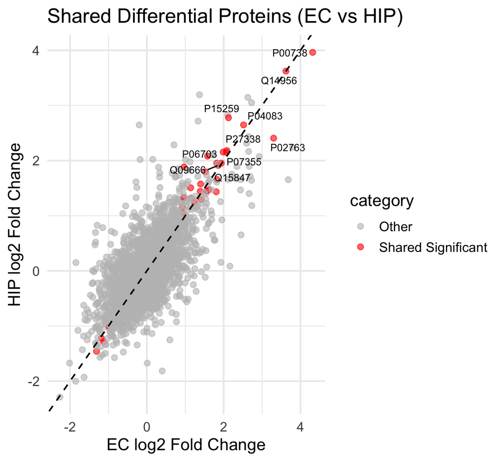

## 4.6.6. Quantify Overlap

length(shared)

#[1] 32

#proportion of shared signal length(shared) / length(common)

#[1] 0.01369863

## 5. Pathway Enrichment Analysis

## 5.1. Extract Significant Proteins

sig_p <- 0.05 sig_lfc <- 0.25

ec_sig <- results_ec %>% as.data.frame() %>% rownames_to_column(“uniprot”) %>% filter(adj.P.Val < sig_p, abs(logFC) > sig_lfc)

hip_sig <- results_hip %>% as.data.frame() %>% rownames_to_column(“uniprot”) %>% filter(adj.P.Val < sig_p, abs(logFC) > sig_lfc)

## 5.2. Map UniProt → Entrez IDs

ec_genes <- bitr( ec_sig$uniprot, fromType = “UNIPROT”, toType = “ENTREZID”, OrgDb = org.Hs.eg.db )

hip_genes <- bitr( hip_sig$uniprot, fromType = “UNIPROT”, toType = “ENTREZID”, OrgDb = org.Hs.eg.db )

## 5.3. Check mapping - QC step

nrow(ec_genes)

#[1] 296

nrow(hip_genes) #[1] 53

# These numbers suggest that both groups will be relatively stable for GO analysis, but KEGG is expected to be very sparse for the hip dataset. Therefore, continue with GO analysis.

##Additional QC to check protein number before mapping

nrow(ec_sig) #[1] 301

nrow(hip_sig) #[1] 52

nrow(ec_genes) #[1] 296

nrow(hip_genes) #[1] 53

##This shows that there is good mapping coverage. It’s just that the HIP dataset has a much smaller DE signal than EC

## 5.4. Compare clusters

gene_list <- list( EC = ec_genes$ENTREZID, HIP = hip_genes$ENTREZID )

cc_go <- compareCluster( geneCluster = gene_list, fun = “enrichGO”, OrgDb = org.Hs.eg.db, ont = “BP”, keyType = “ENTREZID” )

## 5.5. Create Dotplot

dotplot(cc_go, showCategory = 15, title = “GO Biological Process: EC vs HIP”)

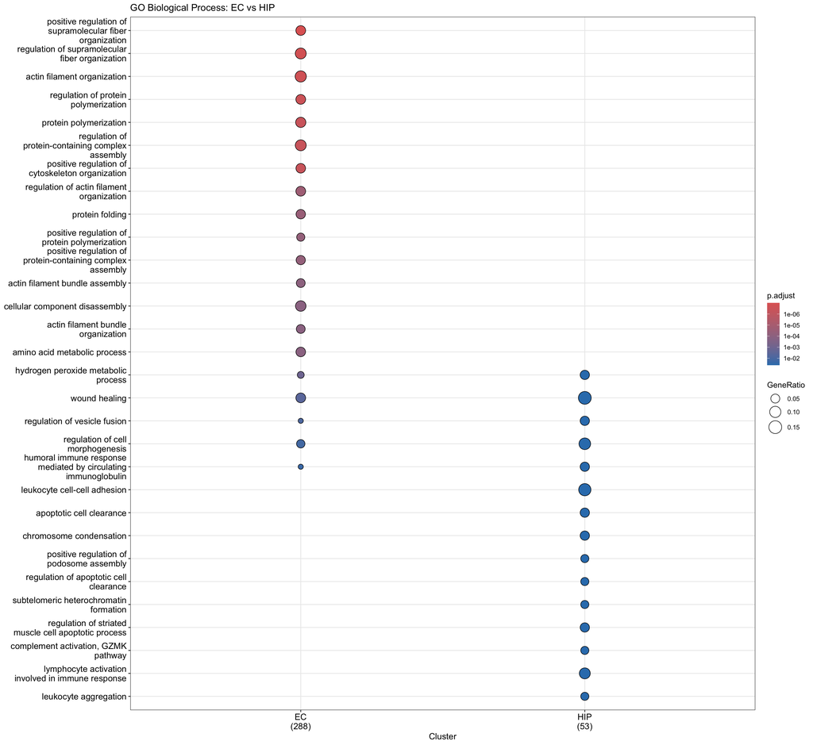

## 5.6. Identify shared pathways between EC and HIP and plot them

#Step 1 — Get the 9 shared pathways ec_df <- as.data.frame(ec_go) hip_df <- as.data.frame(hip_go)

shared_ids <- intersect(ec_df$ID, hip_df$ID)

shared_df <- ec_df[ec_df$ID %in% shared_ids, c(“ID”, “Description”, “p.adjust”)]

#Step 2 — Make sure it’s clean shared_df <- na.omit(shared_df) shared_df <- shared_df[order(shared_df$p.adjust), ]

#Step 3 — Convert to grid table tbl <- gridExtra::tableGrob(shared_df)

#Step 4 — Save as PNG png(“shared_pathways.png”, width = 2200, height = 1200, res = 300)

grid::grid.draw(tbl)

dev.off()

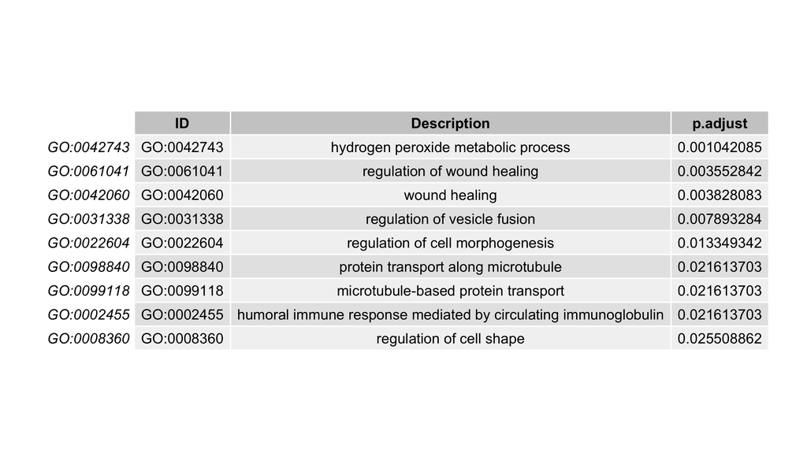

## 6. Visualisations (EC-HIP comparison)

##6.1. Heatmap

#STEP 1 — Build combined pathway table by merging EC + HIP enrichment results ec_df <- as.data.frame(ec_go) hip_df <- as.data.frame(hip_go) ##Keep only shared pathways shared_ids <- intersect(ec_df$ID, hip_df$ID)

ec_shared <- ec_df[ec_df$ID %in% shared_ids, ] hip_shared <- hip_df[hip_df$ID %in% shared_ids, ]

#STEP 2 — Build heatmap matrix by using −log10(p.adjust) ec_shared$score <- -log10(ec_shared$p.adjust) hip_shared$score <- -log10(hip_shared$p.adjust) ##Combine into one table library(dplyr)

heat_df <- full_join( ec_shared[, c(“ID”, “Description”, “score”)], hip_shared[, c(“ID”, “score”)], by = “ID”, suffix = c(“_EC”, “_HIP”) ) #Replace missing values with 0 heat_df[is.na(heat_df)] <- 0

#Use description as rownames rownames(heat_df) <- heat_df$Description heat_matrix <- as.matrix(heat_df[, c(“score_EC”, “score_HIP”)])

#STEP 3 — Create heatmap pheatmap( heat_matrix, cluster_rows = TRUE, cluster_cols = FALSE, color = colorRampPalette(c(“white”, “red”))(100), main = “Shared Pathway Enrichment (EC vs HIP)” )

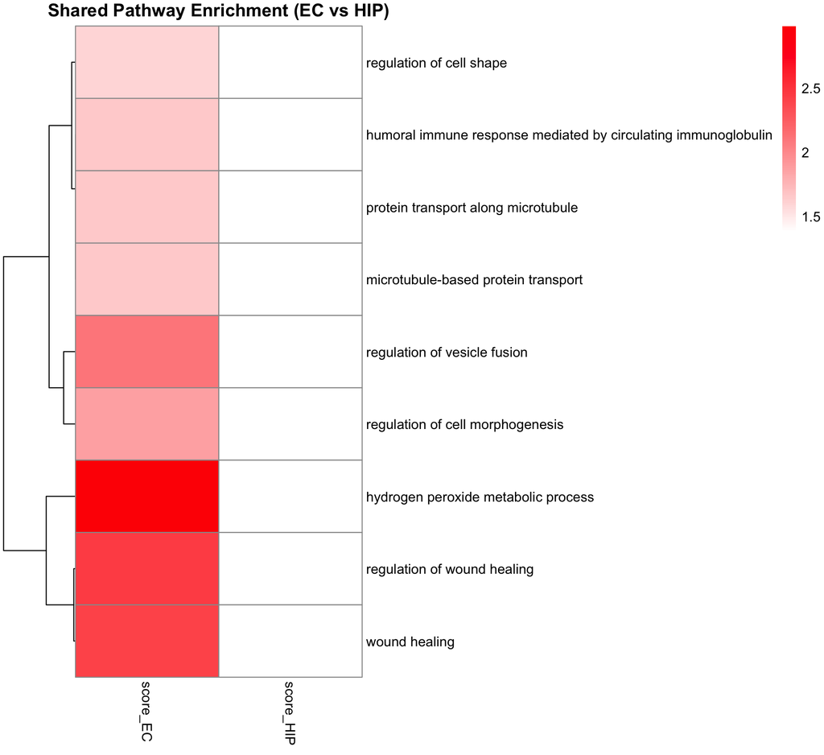

## 6.2. Venn Diagram

#Step 1 — define the two sets ec_set <- ec_genes$ENTREZID hip_set <- hip_genes$ENTREZID

#Step 2 — create Venn plot venn.plot <- venn.diagram( x = list( EC = ec_set, HIP = hip_set ), filename = NULL, fill = c(“steelblue”, “tomato”), alpha = 0.5, cex = 1.5, cat.cex = 1.3, cat.pos = 0 )

#Step 3 — display venn plot grid.newpage() grid.draw(venn.plot)

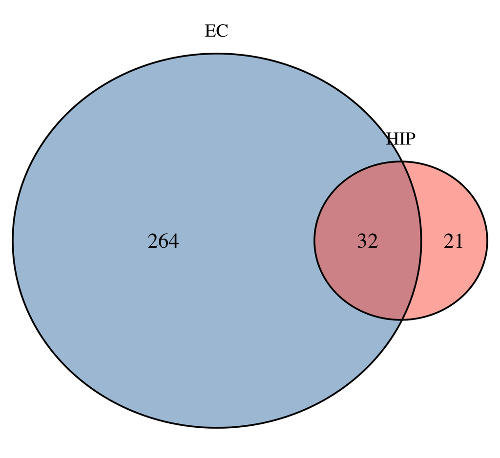